# Model VECM

Jakub Augustynek

1/24/2020

Podstawowym etapem budowy modelu VAR jest sprawdzenie stacjonarności zmiennych, w przypadku braku stacjonarności konieczne jest przekształcenie modelu przez np. obliczenie przyrostów. Tak oszacowany model informuje tylko o zależnościach krótkoterminowych. Johansen zaproponował, by **badać długokokresową relację** między zmiennymi za pomocą modelu VAR uzupełnionego o **składnik korekty błędem** wyrażający długookresową relację pomiędzy zmiennymi niestacjonarnymi. Oznacza to przekształcenie modelu VAR do postaci wektorowego modelu korekty błędem **VECM**.

Model zbudowany będzie dla wartości zamknięcia podanych indeksów giełdowych:

- **DAX** - niemiecki indeks akcji
- **FTSE** - brytyjski indeks akcji
- **SHC** - chiński indeks giełdowy
- **SPX** - amerykański indeks giełdowy
- **WIG20** - polski indeks giełdowy

## Przygotowanie danych

W projekcie tym wykorzystano dane użyte w poprzednim projekcie. Zostały pobrane ze strony (https://stooq.pl). Pobrano dzienne dane historyczne indeksów od stycznia 2010 roku do grudnia 2019.

```r
library(readr)
library(kableExtra)
library(dplyr)
dax <- read_csv("data/^dax_d.csv")
dax<-dax[,c(1,5)]
ftse <- read_csv("data/^ftm_d.csv")
ftse<-ftse[,c(1,5)]
shc <- read_csv("data/^shc_d.csv")
shc<-shc[,c(1,5)]
spx <- read_csv("data/^spx_d.csv")
spx<-spx[,c(1,5)]
wig20 <- read_csv("data/wig20_d.csv")
wig20<-wig20[,c(1,5)]
```

Dane uporządkowano połączono w jeden data frame według daty.

Ponieważ występowały braki danych, zastosowano **interpolację liniową**. W interpolacji używana jest ostatnia ważna wartość przed brakiem danych oraz pierwsza ważna za brakiem. Jeśli braki danych występują w pierwszej lub ostatniej obserwacji w serii, nie są one zastępowane. Użyta do tego została funkcja *na.approx*.

Wykorzystano wartości zamknięcia indeksów giełdowych. W celu wygładzenia danych, zlogarytmowano je.

| Data | DAX | FTSE | SHC | SPX | WIG20 |
| --- | --- | --- | --- | --- | --- |
| 2010-01-04 | 8.707532 | 9.160111 | 8.084488 | 7.032615 | 7.801629 |
| 2010-01-05 | 8.704811 | 9.165039 | 8.096263 | 7.035726 | 7.808851 |
| 2010-01-06 | 8.705220 | 9.168427 | 8.087708 | 7.036272 | 7.813118 |
| 2010-01-07 | 8.702736 | 9.172678 | 8.068647 | 7.040265 | 7.798277 |
| 2010-01-08 | 8.705763 | 9.178752 | 8.069655 | 7.043142 | 7.799925 |
| 2010-01-11 | 8.706242 | 9.182603 | 8.074882 | 7.044888 | 7.813389 |
| 2010-01-12 | 8.689969 | 9.169880 | 8.093759 | 7.035462 | 7.803317 |
| 2010-01-13 | 8.693352 | 9.166338 | 8.062326 | 7.043754 | 7.807124 |
| 2010-01-14 | 8.697660 | 9.166183 | 8.075754 | 7.046177 | 7.804651 |
| 2010-01-15 | 8.678626 | 9.163060 | 8.078425 | 7.035295 | 7.800728 |
| 2010-01-18 | 8.685847 | 9.166605 | 8.082433 | 7.041525 | 7.810069 |
| 2010-01-19 | 8.695587 | 9.164863 | 8.085447 | 7.047717 | 7.819805 |
| 2010-01-20 | 8.674458 | 9.156126 | 8.055745 | 7.037063 | 7.819817 |
| 2010-01-21 | 8.656428 | 9.150386 | 8.057966 | 7.017936 | 7.812180 |
| 2010-01-22 | 8.647400 | 9.140478 | 8.048338 | 6.995546 | 7.786460 |
| 2010-01-25 | 8.636108 | 9.137030 | 8.037353 | 7.000134 | 7.790642 |
| 2010-01-26 | 8.642756 | 9.137008 | 8.012810 | 6.995922 | 7.778479 |
| 2010-01-27 | 8.638207 | 9.131865 | 8.001894 | 7.000790 | 7.772083 |
| 2010-01-28 | 8.619809 | 9.128455 | 8.004412 | 6.988902 | 7.767658 |
| 2010-01-29 | 8.632090 | 9.131005 | 8.002791 | 6.979024 | 7.775964 |
| 2010-02-01 | 8.640203 | 9.139071 | 7.986627 | 6.993180 | 7.767763 |
| 2010-02-02 | 8.649915 | 9.157021 | 7.984364 | 7.006079 | 7.772479 |
| 2010-02-03 | 8.643313 | 9.150358 | 8.007643 | 7.000590 | 7.776514 |
| 2010-02-04 | 8.618529 | 9.129547 | 8.004803 | 6.968954 | 7.734533 |
| 2010-02-05 | 8.600493 | 9.108962 | 7.985961 | 6.971847 | 7.694233 |
| 2010-02-08 | 8.609745 | 9.106131 | 7.984521 | 6.962944 | 7.691360 |
| 2010-02-09 | 8.612187 | 9.107201 | 7.989167 | 6.975900 | 7.698605 |
| 2010-02-10 | 8.619094 | 9.112101 | 8.000517 | 6.973665 | 7.703075 |
| 2010-02-11 | 8.613218 | 9.119086 | 8.001523 | 6.983299 | 7.683979 |
| 2010-02-12 | 8.612574 | 9.110848 | 8.012393 | 6.980550 | 7.703779 |

[output cut: 2555 more lines]

## Badanie stacjonarności zmiennych

Wstępne badanie, czy zjawisko należy do szeregów stacjonarnych, czy niestacjonarnych można przeprowadzić na podstawie analizy wykresów. Należy zwrócić uwagę, czy wartości szeregu wyraźnie rosną, lub maleją, może to świadczyć o tym, że proces jest niestacjonarny.

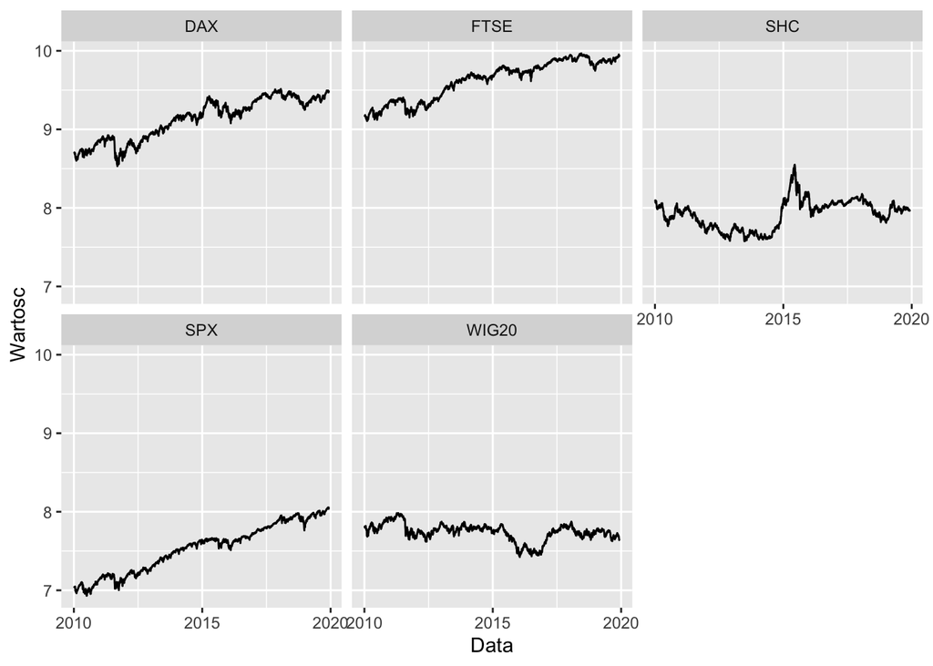

Na powyższych wykresach można zauważyć, że indeksy DAX, FTSE, SPX rosną, wskazuje to na ich niestacjonarność.

## Następnie przeprowadzony zostanie test ADF.

Jego hipotezy są następujące:

**H0: Niestacjonarność zmiennej**

**H1: Stacjonarność zmiennej**

```
##
##  Augmented Dickey-Fuller Test
##
## data:  daneL$DAX
## Dickey-Fuller = -2.7883, Lag order = 13, p-value = 0.2446
## alternative hypothesis: stationary
```

```
##
##  Augmented Dickey-Fuller Test
##
## data:  daneL$FTSE
## Dickey-Fuller = -2.5932, Lag order = 13, p-value = 0.3272
## alternative hypothesis: stationary
```

```
##
##  Augmented Dickey-Fuller Test
##
## data:  daneL$SHC
## Dickey-Fuller = -2.5772, Lag order = 13, p-value = 0.3339
## alternative hypothesis: stationary
```

```
##
##  Augmented Dickey-Fuller Test
##
## data:  daneL$SPX
## Dickey-Fuller = -3.5514, Lag order = 13, p-value = 0.03733
## alternative hypothesis: stationary
```

```
##
##  Augmented Dickey-Fuller Test
##
## data:  daneL$WIG20
## Dickey-Fuller = -2.6875, Lag order = 13, p-value = 0.2872
## alternative hypothesis: stationary
```

## Wybór rzędu opóźnień

Przy pomocy funkcji VARselect wybrany zostanie odpowiedni rząd opóźnień. Oblicza ona cztery kryteria informacyjne: Akaike’a **AIC**, Hannana i Quinna **HQ**, Schwartza **SC** oraz Final Prediction Error **FPE**.

```r
library(vars)
VARselect(daneL[,2:6])
```

```
## $selection
## AIC(n)  HQ(n)  SC(n) FPE(n)
##      6      2      2      6
##
## $criteria
##                    1             2             3             4             5
## AIC(n) -4.746393e+01 -4.763135e+01 -4.764047e+01 -4.763728e+01 -4.764273e+01
## HQ(n)  -4.743921e+01 -4.758603e+01 -4.757455e+01 -4.755076e+01 -4.753560e+01
## SC(n)  -4.739574e+01 -4.750632e+01 -4.745861e+01 -4.739859e+01 -4.734720e+01
## FPE(n)  2.435988e-21  2.060475e-21  2.041771e-21  2.048289e-21  2.037176e-21
##                    6             7             8             9            10
## AIC(n) -4.764862e+01 -4.764294e+01 -4.763456e+01 -4.762801e+01 -4.762095e+01
## HQ(n)  -4.752089e+01 -4.749461e+01 -4.746563e+01 -4.743848e+01 -4.741081e+01
## SC(n)  -4.729627e+01 -4.723375e+01 -4.716855e+01 -4.710517e+01 -4.704127e+01
## FPE(n)  2.025207e-21  2.036759e-21  2.053899e-21  2.067403e-21  2.082075e-21
```

## Badanie stacjonarności reszt modelu VAR(3)

By móc interpretować istotność zmiennych, reszty z modelu VAR muszą być stacjonarne. Testuję stacjonarność za pomocą testu adf.

```
##
##  Augmented Dickey-Fuller Test
##
## data:  reszty3$DAX
## Dickey-Fuller = -13.415, Lag order = 13, p-value = 0.01
## alternative hypothesis: stationary
```

```
##
##  Augmented Dickey-Fuller Test
##
## data:  reszty3$FTSE
## Dickey-Fuller = -13.339, Lag order = 13, p-value = 0.01
## alternative hypothesis: stationary
```

```
##
##  Augmented Dickey-Fuller Test
##
## data:  reszty3$SHC
## Dickey-Fuller = -12.479, Lag order = 13, p-value = 0.01
## alternative hypothesis: stationary
```

```
##
##  Augmented Dickey-Fuller Test
##
## data:  reszty3$SPX
## Dickey-Fuller = -14.432, Lag order = 13, p-value = 0.01
## alternative hypothesis: stationary
```

```
##
##  Augmented Dickey-Fuller Test
##
## data:  reszty3$WIG20
## Dickey-Fuller = -13.522, Lag order = 13, p-value = 0.01
## alternative hypothesis: stationary
```

Dla każdego przeptowadzonego testu p -value jest mniejsze od poziomu istotności, odrzucamy hipotezę zerową mówiącą o niestacjonarności. **Reszty są stacjonarne**.

## Sprawdzanie autokorelacji modelu VAR zbudowanego na resztach

W celu przetestowania występowania autokorelacji krzyżowej użyta zostanie funkcja serial.test, test Breuscha-Godfreya. Funkcja ta jako argument przyjmuje model, dlatego by móc sprawdzić autokorelację krzyżową reszt, **zbudowany został model VAR dla reszt z poprzedniego modelu VAR.**

Hipotezy testu Breuscha-Godfreya są następujące:

**H0: Autokorelacja reszt nie wystepuje**

**H1: Autokorelcja reszt jest istotna statystycznie**

```r
VAR3reszt<-VAR(reszty3, p=1)
serial.test(VAR3reszt, lags.bg = 6, type = "BG")
```

```
##
##  Breusch-Godfrey LM test
##
## data:  Residuals of VAR object VAR3reszt
## Chi-squared = 215.4, df = 150, p-value = 0.000373
```

## Test Johansena

Badanie kointegracji szeregów czasowych przeprowadzono za pomocą testu Johansena: testu maksymalnej wartości własnej i testu śladu. W teście tym hipoteza zerowa jest następująca:

**H0: Brak kointegracji rzędu r**

**H1: Występowanie kointegracji**

```r
#test johansena w celu sprawdzenia kointegracji
j1<-ca.jo(daneL[,2:6], type = "eigen")
j2<-ca.jo(daneL[,2:6], type="trace")
summary(j1)
```

```
##
## ######################
## # Johansen-Procedure #
## ######################
##
## Test type: maximal eigenvalue statistic (lambda max) , with linear trend
##
## Eigenvalues (lambda):
## [1] 0.0143173210 0.0058016982 0.0041618009 0.0017710173 0.0002020347
##
## Values of teststatistic and critical values of test:
##
##           test 10pct  5pct  1pct
## r <= 4 |  0.52  6.50  8.18 11.65
## r <= 3 |  4.58 12.91 14.90 19.19
## r <= 2 | 10.77 18.90 21.07 25.75
## r <= 1 | 15.03 24.78 27.14 32.14
## r = 0  | 37.25 30.84 33.32 38.78
##
## Eigenvectors, normalised to first column:
## (These are the cointegration relations)
##
##               DAX.l2   FTSE.l2    SHC.l2     SPX.l2  WIG20.l2
## DAX.l2    1.00000000  1.000000  1.000000  1.0000000   1.00000
## FTSE.l2  -1.01825586  4.623706  4.567332  1.5489279  29.74966
## SHC.l2   -0.13048009 -1.260643 -2.628243  0.6425471 -18.24266
## SPX.l2   -0.01902743 -3.180571 -4.266353 -2.3427742 -54.40307
## WIG20.l2 -0.11608419  2.974888 -4.265331 -0.4883677  37.66487
##
## Weights W:
## (This is the loading matrix)
##
##               DAX.l2       FTSE.l2       SHC.l2        SPX.l2      WIG20.l2
## DAX.d   -0.012182607 -0.0008953807 0.0005491099 -1.447066e-03  2.597912e-06
## FTSE.d   0.008092885 -0.0008696554 0.0002435744 -7.719427e-04  4.194299e-06
## SHC.d    0.026352589  0.0009258804 0.0004346467 -1.557495e-03 -4.932342e-07
## SPX.d   -0.005513901 -0.0001410076 0.0006040620 -2.721759e-04  7.174446e-06
## WIG20.d  0.007286036 -0.0008241852 0.0009553840 -7.796038e-05 -1.894180e-06
```

```r
summary(j2)
```

```
##
## ######################
## # Johansen-Procedure #
## ######################
##
## Test type: trace statistic , with linear trend
##
## Eigenvalues (lambda):
## [1] 0.0143173210 0.0058016982 0.0041618009 0.0017710173 0.0002020347
##
## Values of teststatistic and critical values of test:
##
##           test 10pct  5pct  1pct
## r <= 4 |  0.52  6.50  8.18 11.65
## r <= 3 |  5.10 15.66 17.95 23.52
## r <= 2 | 15.87 28.71 31.52 37.22
## r <= 1 | 30.90 45.23 48.28 55.43
## r = 0  | 68.15 66.49 70.60 78.87
##
## Eigenvectors, normalised to first column:
## (These are the cointegration relations)
##
##               DAX.l2   FTSE.l2    SHC.l2     SPX.l2  WIG20.l2
## DAX.l2    1.00000000  1.000000  1.000000  1.0000000   1.00000
## FTSE.l2  -1.01825586  4.623706  4.567332  1.5489279  29.74966
## SHC.l2   -0.13048009 -1.260643 -2.628243  0.6425471 -18.24266
## SPX.l2   -0.01902743 -3.180571 -4.266353 -2.3427742 -54.40307
## WIG20.l2 -0.11608419  2.974888 -4.265331 -0.4883677  37.66487
##
## Weights W:
## (This is the loading matrix)
##
##               DAX.l2       FTSE.l2       SHC.l2        SPX.l2      WIG20.l2
## DAX.d   -0.012182607 -0.0008953807 0.0005491099 -1.447066e-03  2.597912e-06
## FTSE.d   0.008092885 -0.0008696554 0.0002435744 -7.719427e-04  4.194299e-06
## SHC.d    0.026352589  0.0009258804 0.0004346467 -1.557495e-03 -4.932342e-07
## SPX.d   -0.005513901 -0.0001410076 0.0006040620 -2.721759e-04  7.174446e-06
## WIG20.d  0.007286036 -0.0008241852 0.0009553840 -7.796038e-05 -1.894180e-06
```

## Budowa modelu VECM

Zbudowany został model VECM z 2 opóźnieniami (model VECM buduje się z opóźnieniami mniejszymi o 1 niż w modelu VAR) i jedną relacją kointegrującą.

```r
library(tsDyn)
vecm<-VECM(daneL[,2:6], lag=2, r=1)
summary(vecm)
```

```
## #############
## ###Model VECM
## #############
## Full sample size: 2585   End sample size: 2582
## Number of variables: 5   Number of estimated slope parameters 60
## AIC -123001.9    BIC -122627.1   SSR 1.454823
## Cointegrating vector (estimated by 2OLS):
##    DAX       FTSE         SHC        SPX      WIG20
## r1   1 -0.7089016 -0.09424714 -0.2366512 0.02887969
##
##
##                ECT                 Intercept           DAX -1
## Equation DAX   -0.0166(0.0060)**   0.0002(0.0002)      -0.0641(0.0349).
## Equation FTSE  -0.0010(0.0045)     0.0002(0.0002)      -0.0473(0.0259).
## Equation SHC   0.0191(0.0067)**    -0.0002(0.0003)     0.0281(0.0390)
## Equation SPX   -0.0060(0.0048)     0.0004(0.0002)*     0.0330(0.0278)
## Equation WIG20 -0.0022(0.0058)     -0.0002(0.0002)     -0.0304(0.0334)
##                FTSE -1            SHC -1              SPX -1
## Equation DAX   -0.0764(0.0444).   -0.0385(0.0180)*    0.3524(0.0331)***
## Equation FTSE  -0.0592(0.0330).   -0.0338(0.0133)*    0.3448(0.0246)***
## Equation SHC   0.0090(0.0496)     0.0065(0.0201)      0.2464(0.0370)***
## Equation SPX   0.0221(0.0354)     -0.0007(0.0143)     -0.0648(0.0264)*
## Equation WIG20 -0.0970(0.0425)*   -0.0028(0.0172)     0.2982(0.0317)***
##                WIG20 -1            DAX -2              FTSE -2
## Equation DAX   -0.0259(0.0257)     -0.0869(0.0348)*    0.0644(0.0434)
## Equation FTSE  -0.0107(0.0191)     -0.0936(0.0258)***  0.0394(0.0322)
## Equation SHC   0.0025(0.0287)      -0.0180(0.0389)     0.0235(0.0485)
## Equation SPX   -0.0088(0.0205)     -0.0480(0.0277).    0.0932(0.0346)**
## Equation WIG20 -0.0158(0.0246)     -0.0626(0.0333).    0.0404(0.0415)
##                SHC -2              SPX -2              WIG20 -2
## Equation DAX   -0.0102(0.0178)     0.1013(0.0343)**    -0.0219(0.0257)
## Equation FTSE  0.0008(0.0132)      0.1155(0.0255)***   -0.0233(0.0191)
## Equation SHC   -0.0318(0.0199)     0.0524(0.0383)      -0.0162(0.0287)
## Equation SPX   -0.0057(0.0142)     -0.0040(0.0274)     -0.0254(0.0205)
## Equation WIG20 0.0019(0.0170)      0.1512(0.0328)***   -0.0779(0.0246)**
```

## Szacowanie wpływu indeksu SPX na pozostałe indeksy giełdowe

Dla wyestymowanego modelu VECM za pomocą funkcji reakcji na bodziec szacowany będzie wpływ jednego sektora na drugi. Jako impuls wybrany został indeks SPX, ponieważ jest to jeden z najbardziej znanych i wpływowych indeksów na świecie. Jego wpływ na badane w tym projekcie indeksy może być znaczący.

### wpływ na indeks DAX

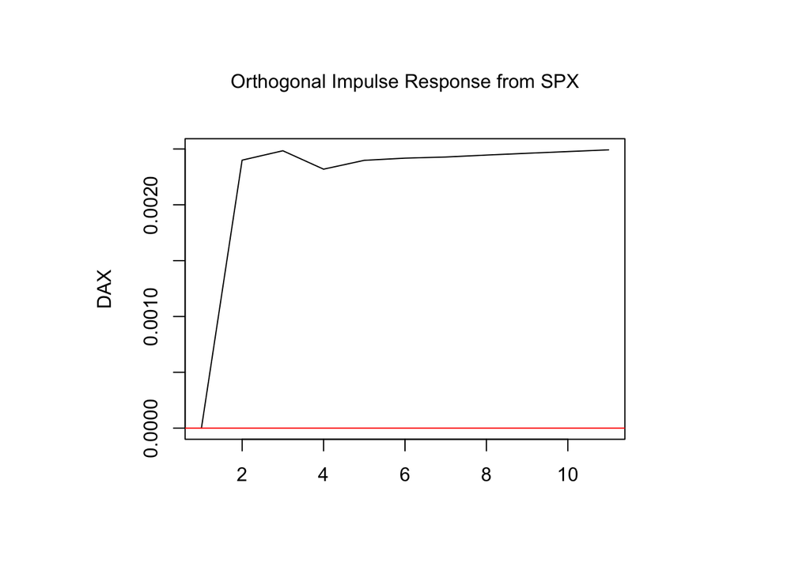

### wpływ na indeks FTSE

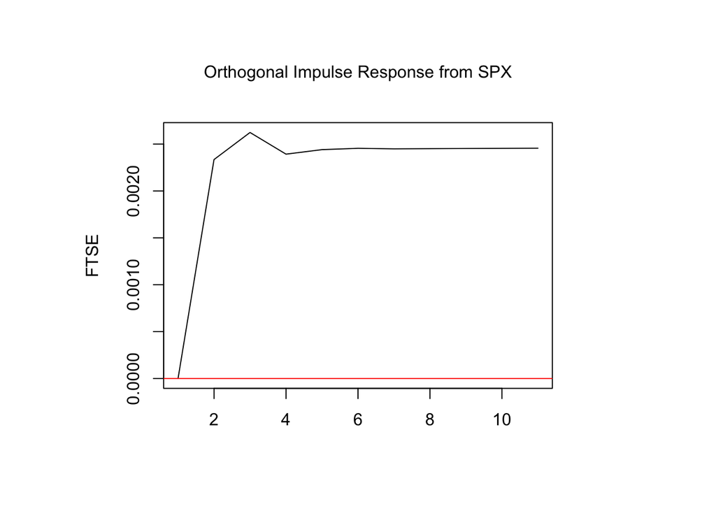

### wpływ na indeks SHC

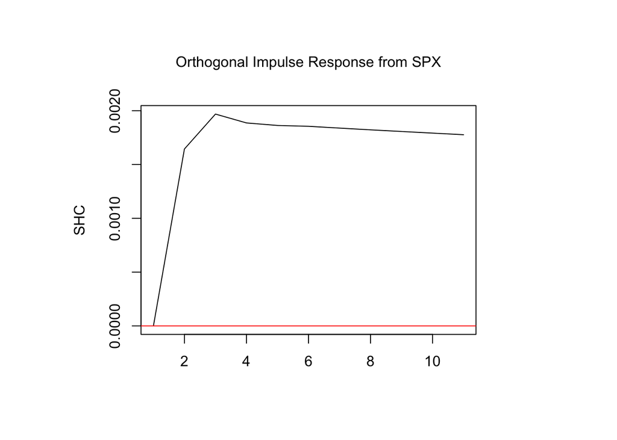

Wpływ indeksu SPX na indeks SHC gwałtownie rośnie, w trzecim dniu osiąga wartość maksymalną, następnie w czwartym minimalnie spada i się stabilizuje.

### wpływ na indeks WIG20

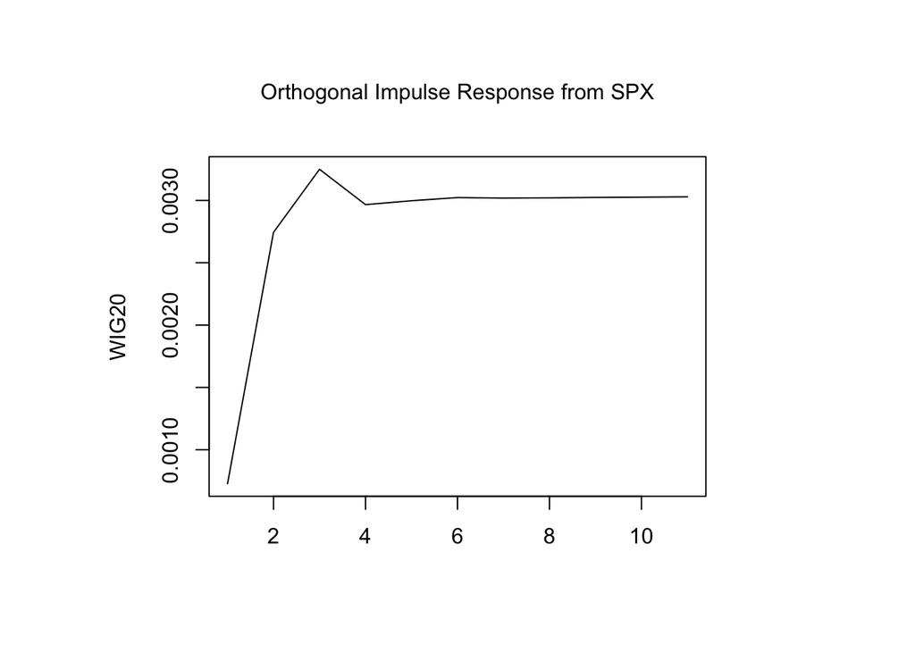

Wpływ indeksu SPX na indeks WIG20 gwałtownie rośnie, w trzecim dniu osiąga wartość maksymalną, następnie w czwartym spada i się stabilizuje. Wpływ na indeks WIG20 jest największy.